# racial bias and gender bias in 2012 election

#introduction The 2012 U.S. presidential election was held on Tuesday, November 6, 2012. This is the 57th U.S. presidential election. Meanwhile, all 435 seats in the house of Representatives and 33 seats in the Senate will be re elected to produce the 113th U.S. Congress. The electoral college will be elected first, and then the president and vice president will be elected by the electoral college on December 17, 2012. The incumbent President Barack Obama and Vice President Joe Biden, as qualified candidates, announced their bid for re-election and successfully won the Democratic nomination. The other major party, the Republican Party, nominated former Massachusetts Governor Mitt Romney as the presidential candidate, and congressman Paul Ryan as his deputy. In addition, some candidates representing other political parties and independents participated in the presidential election. Finally, Barack Obama, representing the Democratic Party, won more than half of the electoral votes in the presidential election, defeated Mitt Romney, the Republican Party, by 332 votes to 206 votes, and was re elected as the president of the United States. Mr Obama is America’s first black president, I want to research if there exist bias in the election for president as well as the parties the candidates support, especially racial bias.

#data process #install the packages

#import the data

```r
library(haven)
anes_timeseries_2012 <-
    read_sav("~/Documents/GitHub/Spring2021-Project1-Yuqi-Xing/data/anes_timeseries_2012.sav")
```

### Process variables for analysis

```r
anes_new=anes_timeseries_2012%>%
  mutate(
    turnout=as_factor(rvote2012_x),
    vote_for_president=as_factor(presvote2012_x),
    vote_for_USHouse=as_factor(hsevote2012_x),
    vote_for_senvote=as_factor(senvote2012_x),
    race=as_factor(dem_raceeth_x),
    gender=as_factor(gender_respondent_x),
  )

library(data.table)

data.table(anes_new%>%
             select(turnout, vote_for_president, vote_for_USHouse, vote_for_senvote, race, gender)%>%
             filter(turnout!="-9"&turnout!="-6"&turnout!="-2. Missing, 2012 voting status not determined")%>%
             sample_n(10))
```

| turnout | vote_for_president | vote_for_USHouse | vote_for_senvote | race | gender |
| --- | --- | --- | --- | --- | --- |
| 1. R voted in the 2012 elections | 5. Other | 2. Voted for Republican House candidate | 2. Voted for Republican Senate candidate | 1. White, non-Hispanic | 2. Female |
| 1. R voted in the 2012 elections | 5. Other | 2. Voted for Republican House candidate | 2. Voted for Republican Senate candidate | 1. White, non-Hispanic | 1. Male |
| 2. R did not vote in the 2012 elections | -2. R did not vote for Pres or did not report vote for Pres in pre and no post-election data | -1. Inap, R did not or DK/RF if voted; voted but not (or DK/RF if voted for) for U.S. House | -1. Inap, R did not vote or DK/RF if voted; voted but not (or DK/RF if) for us Senate; no us Sen race in state of vote | 1. White, non-Hispanic | 1. Male |
| 1. R voted in the 2012 elections | 1. Barack obama | -1. Inap, R did not or DK/RF if voted; voted but not (or DK/RF if voted for) for U.S. House | 1. Voted for Democratic Senate candidate | 2. Black, non-Hispanic | 1. Male |
| 1. R voted in the 2012 elections | 1. Barack obama | 1. Voted for Democratic House candidate | -1. Inap, R did not vote or DK/RF if voted; voted but not (or DK/RF if) for us Senate; no us Sen race in state of vote | 2. Black, non-Hispanic | 2. Female |
| 2. R did not vote in the 2012 elections | -2. R did not vote for Pres or did not report vote for Pres in pre and no post-election data | -1. Inap, R did not or DK/RF if voted; voted but not (or DK/RF if voted for) for U.S. House | -1. Inap, R did not vote or DK/RF if voted; voted but not (or DK/RF if) for us Senate; no us Sen race in state of vote | 6. Other non-Hispanic incl multiple races (Web: blank 'Other' counted as a race) | 1. Male |
| 2. R did not vote in the 2012 elections | -2. R did not vote for Pres or did not report vote for Pres in pre and no post-election data | -1. Inap, R did not or DK/RF if voted; voted but not (or DK/RF if voted for) for U.S. House | -1. Inap, R did not vote or DK/RF if voted; voted but not (or DK/RF if) for us Senate; no us Sen race in state of vote | 1. White, non-Hispanic | 1. Male |
| 2. R did not vote in the 2012 elections | -2. R did not vote for Pres or did not report vote for Pres in pre and no post-election data | -1. Inap, R did not or DK/RF if voted; voted but not (or DK/RF if voted for) for U.S. House | -1. Inap, R did not vote or DK/RF if voted; voted but not (or DK/RF if) for us Senate; no us Sen race in state of vote | 1. White, non-Hispanic | 2. Female |
| 1. R voted in the 2012 elections | 1. Barack obama | -1. Inap, R did not or DK/RF if voted; voted but not (or DK/RF if voted for) for U.S. House | -1. Inap, R did not vote or DK/RF if voted; voted but not (or DK/RF if) for us Senate; no us Sen race in state of vote | 3. Asian, native Hawaiian or other Pacif Islr, non-Hispanic | 1. Male |
| 1. R voted in the 2012 elections | 2. Mitt romney | 2. Voted for Republican House candidate | 1. Voted for Democratic Senate candidate | 1. White, non-Hispanic | 2. Female |

```r
anes_new = anes_new%>%
  filter(turnout!="-9"&turnout!="-6"&turnout!="-2. Missing, 2012 voting status not determined")%>%
  select(turnout, vote_for_president, vote_for_USHouse, vote_for_senvote, race, gender)
head(anes_new)
```

| turnout | vote_for_president | vote_for_USHouse | vote_for_senvote | race | gender |
| --- | --- | --- | --- | --- | --- |
| 1. R voted in the 2012 elections | 1. Barack obama | -1. Inap, R did not or DK/RF if voted; voted but not (or DK/RF if voted for) for U.S. House | -1. Inap, R did not vote or DK/RF if voted; voted but not (or DK/RF if) for us Senate; no us Sen race in state of vote | 2. Black, non-Hispanic | 1. Male |
| 1. R voted in the 2012 elections | 1. Barack obama | -1. Inap, R did not or DK/RF if voted; voted but not (or DK/RF if voted for) for U.S. House | -1. Inap, R did not vote or DK/RF if voted; voted but not (or DK/RF if) for us Senate; no us Sen race in state of vote | 2. Black, non-Hispanic | 2. Female |
| 1. R voted in the 2012 elections | 1. Barack obama | -1. Inap, R did not or DK/RF if voted; voted but not (or DK/RF if voted for) for U.S. House | -1. Inap, R did not vote or DK/RF if voted; voted but not (or DK/RF if) for us Senate; no us Sen race in state of vote | 2. Black, non-Hispanic | 2. Female |
| 1. R voted in the 2012 elections | 1. Barack obama | -1. Inap, R did not or DK/RF if voted; voted but not (or DK/RF if voted for) for U.S. House | -1. Inap, R did not vote or DK/RF if voted; voted but not (or DK/RF if) for us Senate; no us Sen race in state of vote | 2. Black, non-Hispanic | 1. Male |
| 2. R did not vote in the 2012 elections | -2. R did not vote for Pres or did not report vote for Pres in pre and no post-election data | -1. Inap, R did not or DK/RF if voted; voted but not (or DK/RF if voted for) for U.S. House | -1. Inap, R did not vote or DK/RF if voted; voted but not (or DK/RF if) for us Senate; no us Sen race in state of vote | 2. Black, non-Hispanic | 1. Male |
| 1. R voted in the 2012 elections | 1. Barack obama | -1. Inap, R did not or DK/RF if voted; voted but not (or DK/RF if voted for) for U.S. House | -1. Inap, R did not vote or DK/RF if voted; voted but not (or DK/RF if) for us Senate; no us Sen race in state of vote | 2. Black, non-Hispanic | 2. Female |

```r
save(anes_new, file="~/Documents/GitHub/Spring2021-Project1-Yuqi-Xing/output/data_use.RData")
```

# A simple analysis

#Who went to vote in the election?

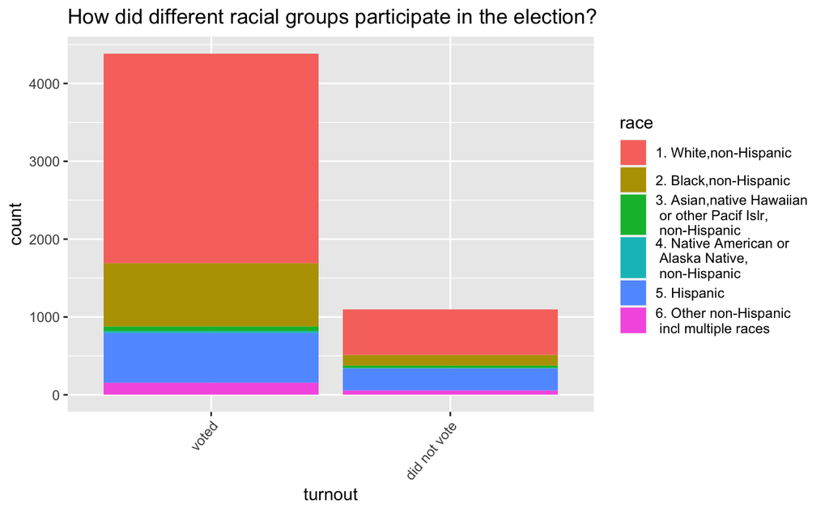

```r
load(file="~/Documents/GitHub/Spring2021-Project1-Yuqi-Xing/output/data_use.RData")
anes_to_race = anes_new %>%
  filter(race!="-9. Missing")     ###delete useless data from race variable

anes_to_gender = anes_new

ggplot(anes_to_race)+
  geom_bar(aes(x=turnout, fill=race)) +
  theme(axis.text.x = element_text(angle = 50, hjust = 1))+
  labs(title="How did different racial groups participate in the election?")+
  scale_x_discrete(labels=c("1. R voted in the 2012 elections" = "voted", "2. R did not vote in the 2012 elections" = "did not vote"))+
  scale_fill_discrete(name="race", breaks=c("1. White, non-Hispanic", "2. Black, non-Hispanic", "3. Asian, native Hawaiian or other Pacif Islr, non-Hispanic","4. Native American or Alaska Native, non-Hispanic","5. Hispanic", "6. Other non-Hispanic incl multiple races (Web: blank 'Other' counted as a race)"), labels=c("1. White,non-Hispanic", "2. Black,non-Hispanic", "3. Asian,native Hawaiian \n or other Pacif Islr, \n non-Hispanic", "4. Native American or \n Alaska Native, \n non-Hispanic", "5. Hispanic", "6. Other non-Hispanic \n incl multiple races"))   ##create bar graph for turnout, according to different race
```

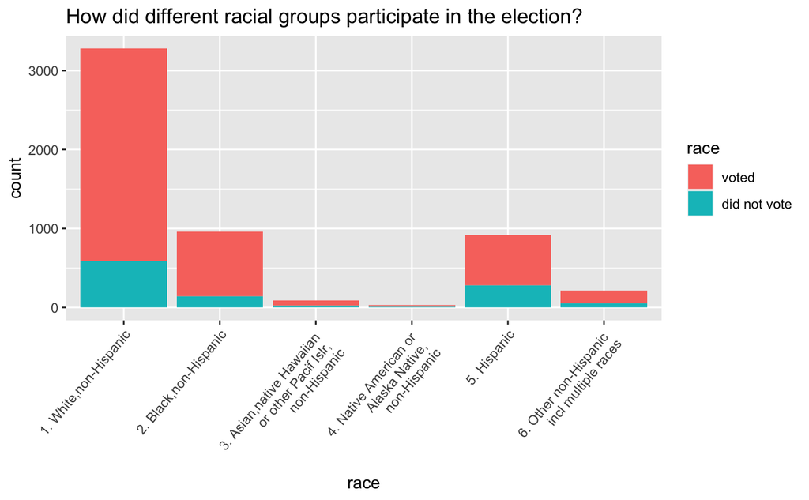

```r
ggplot(anes_to_race)+
  geom_bar(aes(x=race, fill=turnout)) +
  theme(axis.text.x = element_text(angle = 50, hjust = 1))+
labs(title="How did different racial groups participate in the election?")+
scale_x_discrete(labels=c("1. White,non-Hispanic", "2. Black,non-Hispanic", "3. Asian,native Hawaiian \n or other Pacif Islr, \n non-Hispanic", "4. Native American or \n Alaska Native, \n non-Hispanic", "5. Hispanic", "6. Other non-Hispanic \n incl multiple races"))+
  scale_fill_discrete(name="race", breaks=c("1. R voted in the 2012 elections", "2. R did not vote in the 2012 elections"), labels=c("voted", "did not vote"))    #create bar graph for race, according to different turnout
```

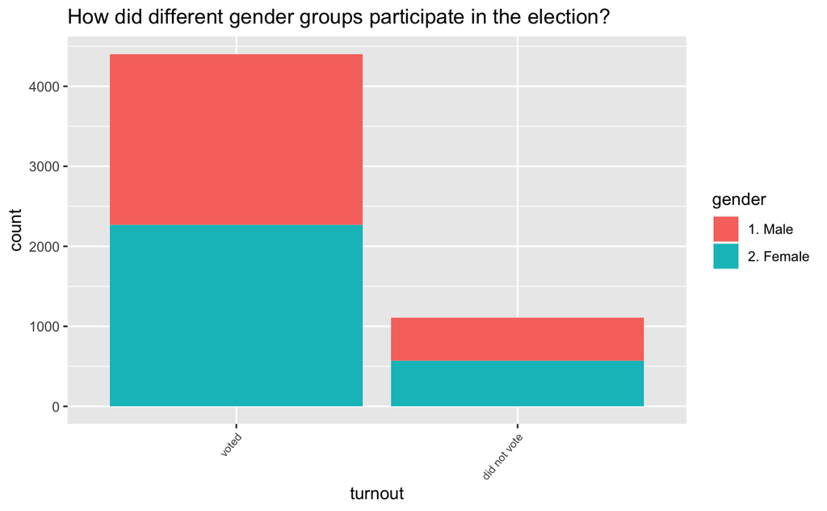

```r
ggplot(anes_to_gender)+
  geom_bar(aes(x=turnout, fill=gender)) +
  theme(axis.text.x = element_text(angle = 50, hjust = 1, size=7))+
  labs(title="How did different gender groups participate in the election?")+
  scale_x_discrete(labels=c("1. R voted in the 2012 elections" = "voted", "2. R did not vote in the 2012 elections" = "did not vote"))     # create bar graph for turnout, according to different gender
```

Overall, most people turned out to vote. For each race, the number of people who voted was significantly greater than the number who did not vote. Because of the large white population in the United States, whites play an important role in voting, like whites voting more than all other races combining. There is no obvious gender bias in voting participation.

#Who did they vote for as president in the election?

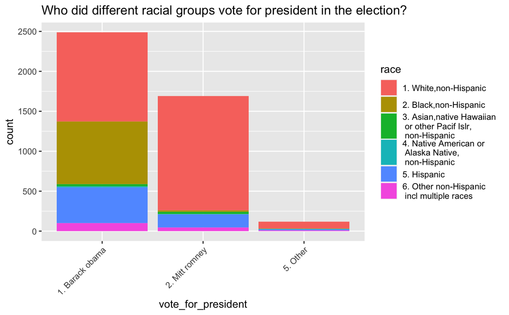

```r
anes_vote_for_president=anes_new %>%
  filter(vote_for_president!="-9"&vote_for_president!="-6"&vote_for_president!="-2. R did not vote for Pres or did not report vote for Pres in pre and no post-election data")   # delete the useless data for vote_for_president variable

anes_vote_for_president_by_race = anes_vote_for_president%>%
  filter(race!="-9. Missing")    # delete the useless race data for vote_for_president variable


anes_vote_for_president_by_gender= anes_vote_for_president

ggplot(anes_vote_for_president_by_race)+
geom_bar(aes(x=vote_for_president, fill=race))+
labs(title="Who did different racial groups vote for president in the election?")+
theme(axis.text.x = element_text(angle = 45, hjust = 1))+
scale_fill_discrete(name="race", breaks=c("1. White, non-Hispanic", "2. Black, non-Hispanic", "3. Asian, native Hawaiian or other Pacif Islr, non-Hispanic","4. Native American or Alaska Native, non-Hispanic","5. Hispanic", "6. Other non-Hispanic incl multiple races (Web: blank 'Other' counted as a race)"), labels=c("1. White,non-Hispanic", "2. Black,non-Hispanic", "3. Asian,native Hawaiian \n or other Pacif Islr, \n non-Hispanic", "4. Native American or \n Alaska Native, \n non-Hispanic", "5. Hispanic", "6. Other non-Hispanic \n incl multiple races"))  ##create bar graph for vote_for_president, according to different race
```

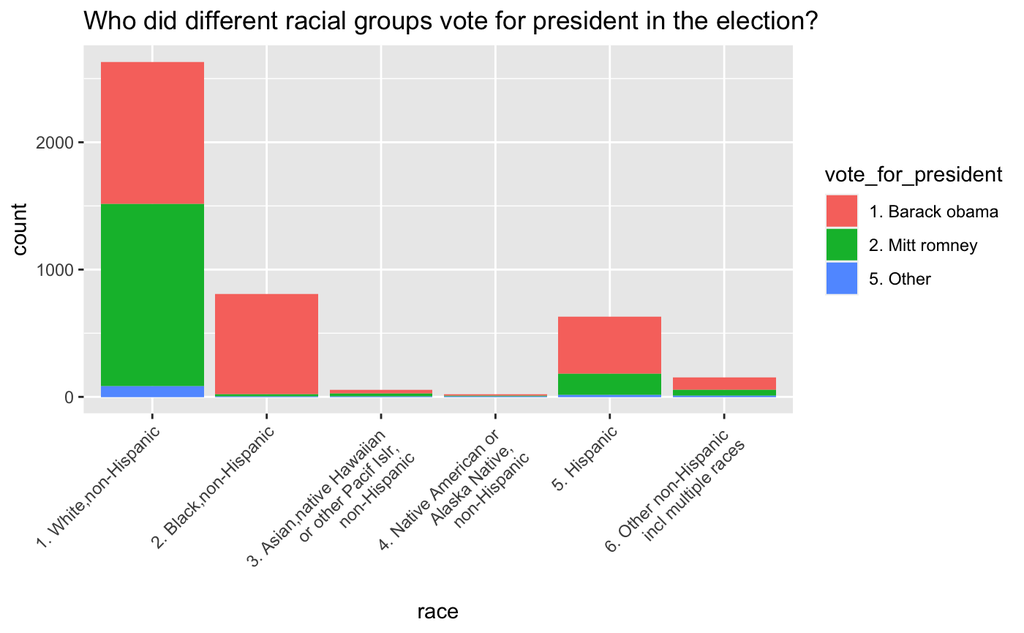

```r
ggplot(anes_vote_for_president_by_race)+
geom_bar(aes(x=race, fill=vote_for_president))+
labs(title="Who did different racial groups vote for president in the election?")+
theme(axis.text.x = element_text(angle = 45, hjust = 1))+
labs(title="Who did different racial groups vote for president in the election?")+
scale_x_discrete(labels=c("1. White,non-Hispanic", "2. Black,non-Hispanic", "3. Asian,native Hawaiian \n or other Pacif Islr, \n non-Hispanic", "4. Native American or \n Alaska Native, \n non-Hispanic", "5. Hispanic", "6. Other non-Hispanic \n incl multiple races"))   #create bar graph for race, according to different vote_for_president
```

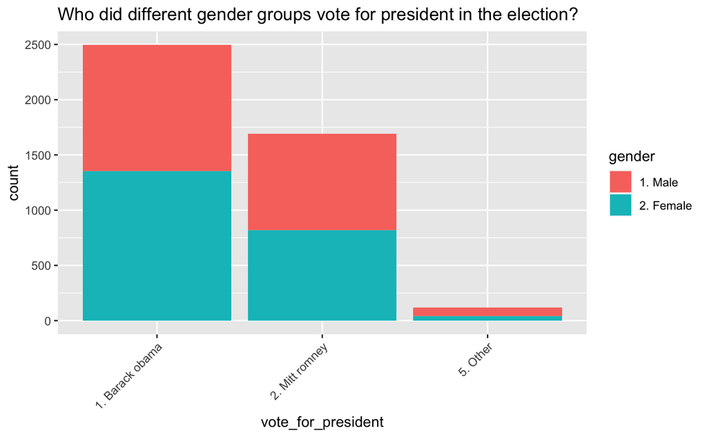

```r
ggplot(anes_vote_for_president_by_gender)+
geom_bar(aes(x=vote_for_president, fill=gender))+
labs(title="Who did different gender groups vote for president in the election?")+
theme(axis.text.x = element_text(angle = 45, hjust = 1))   ##create bar graph for vote_for_president, according to different gender
```

Mr Obama scored significantly higher than the other two. Among whites, nearly half support Barack Obama, but more than half support Mitt Romney. Among blacks, nearly all voted for Obama (Obanma is black, so there may exist racial bias). Among Hispanic, most people voted for Obanma. For the other races, the vote was evenly split, or close to evenly split by Obama and Romney. There is no obvious gender bias in voting for president.

#which party did they vote for as U.S. House in the election?

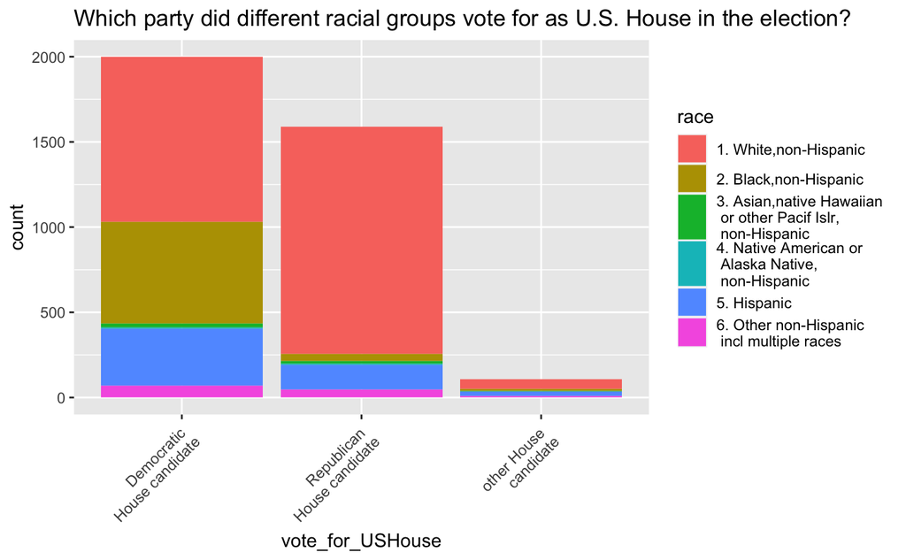

```r
anes_vote_for_USHouse=anes_new %>%
  filter(vote_for_USHouse!="-1. Inap, R did not or DK/RF if voted; voted but not (or DK/RF if voted for) for U.S. House"&vote_for_USHouse!="-6. No post-election data (deleted partial or no post IW) and R did not vote in pre-election (early vote)"&vote_for_USHouse!="-2. Missing, DK/RF for whom R voted")   # delete the useless data for vote_for_USHouse variable

anes_vote_for_USHouse_by_race = anes_vote_for_USHouse%>%
  filter(race!="-9. Missing")   # delete the useless race data for vote_for_USHouse variable


anes_vote_for_USHouse_by_gender= anes_vote_for_USHouse

ggplot(anes_vote_for_USHouse_by_race)+
geom_bar(aes(x=vote_for_USHouse, fill=race))+
theme(axis.text.x = element_text(angle = 45, hjust = 1))+
  scale_x_discrete(labels=c("1. Voted for Democratic House candidate" = "Democratic \n House candidate", "2. Voted for Republican House candidate" = "Republican \n House candidate", "7. Voted for other House candidate" = "other House \n candidate"))+
  labs(title="Which party did different racial groups vote for as U.S. House in the election?")+
  scale_fill_discrete(name="race", breaks=c("1. White, non-Hispanic", "2. Black, non-Hispanic", "3. Asian, native Hawaiian or other Pacif Islr, non-Hispanic","4. Native American or Alaska Native, non-Hispanic","5. Hispanic", "6. Other non-Hispanic incl multiple races (Web: blank 'Other' counted as a race)"), labels=c("1. White,non-Hispanic", "2. Black,non-Hispanic", "3. Asian,native Hawaiian \n or other Pacif Islr, \n non-Hispanic", "4. Native American or \n Alaska Native, \n non-Hispanic", "5. Hispanic", "6. Other non-Hispanic \n incl multiple races"))   ##create bar graph for vote_for_USHouse, according to different race
```

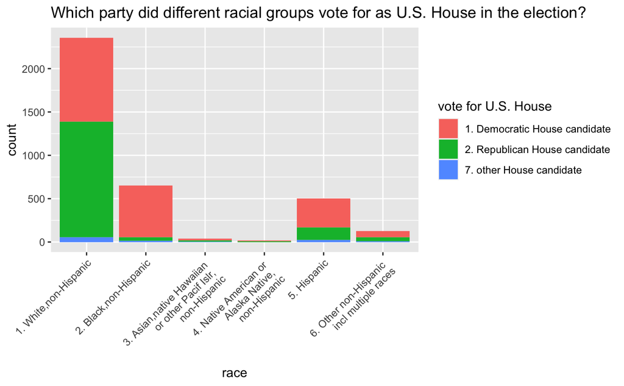

```r
ggplot(anes_vote_for_USHouse_by_race)+
geom_bar(aes(x=race, fill=vote_for_USHouse))+
theme(axis.text.x = element_text(angle = 45, hjust = 1))+
labs(title="Which party did different racial groups vote for as U.S. House in the election?")+
scale_x_discrete(labels=c("1. White,non-Hispanic", "2. Black,non-Hispanic", "3. Asian,native Hawaiian \n or other Pacif Islr, \n non-Hispanic", "4. Native American or \n Alaska Native, \n non-Hispanic", "5. Hispanic", "6. Other non-Hispanic \n incl multiple races"))+
  scale_fill_discrete(name="vote for U.S. House", breaks=c("1. Voted for Democratic House candidate", "2. Voted for Republican House candidate", "7. Voted for other House candidate"), labels=c("1. Democratic House candidate", "2. Republican House candidate", "7. other House candidate"))    ##create bar graph for race, according to different vote_for_USHouse
```

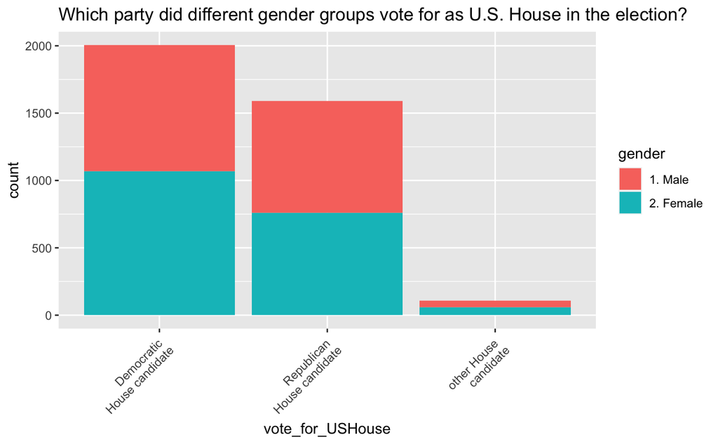

```r
ggplot(anes_vote_for_USHouse_by_gender)+
geom_bar(aes(x=vote_for_USHouse, fill=gender))+
theme(axis.text.x = element_text(angle = 45, hjust = 1))+
  labs(title="Which party did different gender groups vote for as U.S. House in the election?")+
  scale_x_discrete(labels=c("1. Voted for Democratic House candidate" = "Democratic \n House candidate", "2. Voted for Republican House candidate" = "Republican \n House candidate", "7. Voted for other House candidate" = "other House \n candidate"))   ##create bar graph for vote_for_USHouse, according to different gender
```

Overall, the majority favored Democrats, followed by Republicans. Most whites supported the Republicans. Among blacks, nearly all voted for Democrats (Obanma is black & Democrats, so there may exist racial bias). Among Hispanic, most people voted for Democrats. For the other races, the vote was evenly split, or close to evenly split by Democats and Republican. There is no obvious gender bias in voting for USHouse.

#which party did they vote for as Senvote in the election?

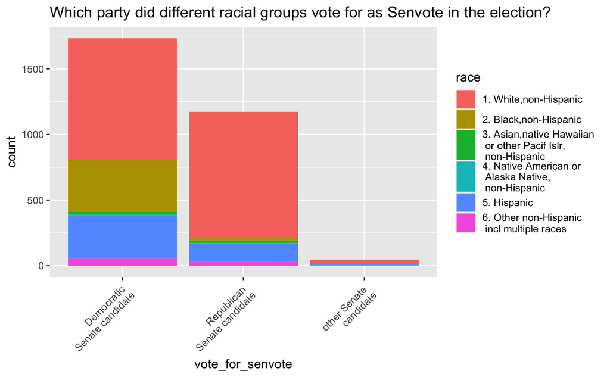

```r
anes_vote_for_senvote=anes_new %>%
  filter(vote_for_senvote!="-1. Inap, R did not vote or DK/RF if voted; voted but not (or DK/RF if) for us Senate; no us Sen race in state of vote"&vote_for_senvote!="-6. No post-election data (deleted partial or no post IW) and R did not vote in pre-election (early vote)"&vote_for_senvote!="-2. Missing, DK/RF for whom R voted")     # delete the useless data for vote_for_senvote variable

anes_vote_for_senvote_by_race = anes_vote_for_senvote%>%
  filter(race!="-9. Missing")    # delete the useless race data for vote_for_senvote variable


anes_vote_for_senvote_by_gender= anes_vote_for_senvote

ggplot(anes_vote_for_senvote_by_race)+
geom_bar(aes(x=vote_for_senvote, fill=race))+
theme(axis.text.x = element_text(angle = 45, hjust = 1))+
labs(title="Which party did different racial groups vote for as Senvote in the election?")+
scale_x_discrete(labels=c("1. Voted for Democratic Senate candidate" = "Democratic \n Senate candidate", "2. Voted for Republican Senate candidate" = "Republican \n Senate candidate", "7. Voted for other Senate candidate" = "other Senate \n candidate"))+
  scale_fill_discrete(name="race", breaks=c("1. White, non-Hispanic", "2. Black, non-Hispanic", "3. Asian, native Hawaiian or other Pacif Islr, non-Hispanic","4. Native American or Alaska Native, non-Hispanic","5. Hispanic", "6. Other non-Hispanic incl multiple races (Web: blank 'Other' counted as a race)"), labels=c("1. White,non-Hispanic", "2. Black,non-Hispanic", "3. Asian,native Hawaiian \n or other Pacif Islr, \n non-Hispanic", "4. Native American or \n Alaska Native, \n non-Hispanic", "5. Hispanic", "6. Other non-Hispanic \n incl multiple races"))    ##create bar graph for vote_for_senvote, according to different race
```

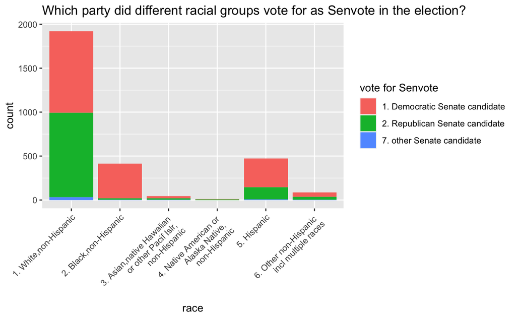

```r
ggplot(anes_vote_for_senvote_by_race)+
geom_bar(aes(x=race, fill=vote_for_senvote))+
theme(axis.text.x = element_text(angle = 45, hjust = 1))+
labs(title="Which party did different racial groups vote for as Senvote in the election?")+
scale_x_discrete(labels=c("1. White,non-Hispanic", "2. Black,non-Hispanic", "3. Asian,native Hawaiian \n or other Pacif Islr, \n non-Hispanic", "4. Native American or \n Alaska Native, \n non-Hispanic", "5. Hispanic", "6. Other non-Hispanic \n incl multiple races"))+
  scale_fill_discrete(name="vote for Senvote", breaks=c("1. Voted for Democratic Senate candidate", "2. Voted for Republican Senate candidate", "7. Voted for other Senate candidate"), labels=c("1. Democratic Senate candidate", "2. Republican Senate candidate", "7. other Senate candidate"))     ##create bar graph for race, according to different vote_for_Senate
```

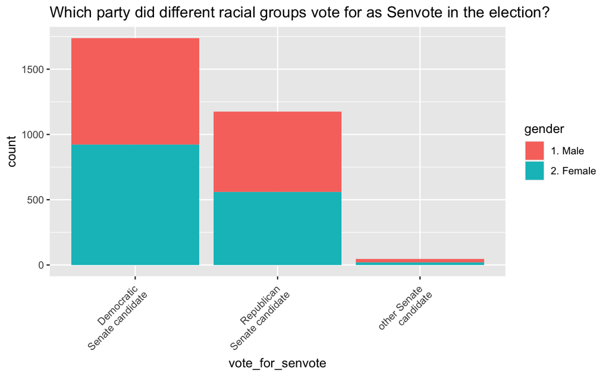

```r
ggplot(anes_vote_for_senvote_by_gender)+
geom_bar(aes(x=vote_for_senvote, fill=gender))+
theme(axis.text.x = element_text(angle = 45, hjust = 1))+
labs(title="Which party did different racial groups vote for as Senvote in the election?")+
scale_x_discrete(labels=c("1. Voted for Democratic Senate candidate" = "Democratic \n Senate candidate", "2. Voted for Republican Senate candidate" = "Republican \n Senate candidate", "7. Voted for other Senate candidate" = "other Senate \n candidate"))    ##create bar graph for vote_for_Senvote, according to different gender
```

Overall, the majority favored Democrats, followed by Republicans. Half of whites voted Democratic and half of whites supported the Republicans. Among blacks, nearly all voted for Democrats (Obanma is black & Democrats, so there may exist racial bias). Among Hispanic, most people voted for Democrats. For the other races, the vote was evenly split, or close to evenly split by Democats and Republican. There is no obvious gender bias in voting for Senate.

#conclusion: There is no obvious gender bias in voting for president, Senvote and U.S House parts of election. Whites have a higher voice because of the large number of whites in the election. The Democrats and the Republicans are basically in a close race for voting for U.S House and Senvote, but the Democrats are a little more likely to vote. The similiar situation happens on Obama and romney.It’s worth noting that almost all blacks voted for Obama and the Democrats, making a influence in this election (blacks have the second largest population, followed by whites). There exists a racial bias for president, U.S House and Senvote in 2012 election.